# Stat 226 - Lecture 7

02/04/14

### Probability...It's as easy as flipping a coin!

[figure not shown]

### Probability made easy

- What's the **probability** that a coin lands heads-up?
- Assuming it's a *fair* coin, the probability is 0.5.
- What's the **probability** that a coin lands tails-up?
- We just fully described a **probability distribution function (pdf)**!

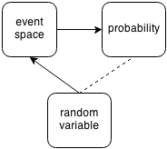

- In essence, a **pdf** assigns **probability** to value(s) of a **random variable**.

Technically, value(s) of a **random variable** define **event(s)** and each **event** has a probability.

Suppose I flip a coin twice. What are the different possible **events**?

Let \( X \) be the # of heads after two flips. What event(s) correspond to \( X=1 \)?

2 out of 4 (equally likely) events lead to \( X=1 \), so \( P(X=1) = 0.5 \).

- What are all the different possible values \( X \)?
- What is the probability \( X \) takes on each value?

probability distribution function for \( X \):

| P(X=0) | P(X=1) | P(X=2) |
| --- | --- | --- |
| 0.25 | .5 | 0.25 |

- Since \( X \) takes on a small # of values, it is a **discrete** random variable (think categorical).
- From now on, we study **continuous** random variables (can you guess the difference?)
- **Continuous** random variables can take on an infinite number of values (think quantitative)!
- **Events** are defined by **intervals:** \( X \leq 0 \), not \( X=0 \)
- **IMPORTANT**: probabilities are **always** between 0 and 1! pdfs **always** add to 1!

[figure not shown]

### Back to normal distributions

- The **Normal distribution** is a special type of **pdf**.
- A **normal** random variable is a **continous** random variable whose **pdf** is **symmetric** and **bell-shaped**.
- If \( X \) is a normally distributed random variable, it has a mean \( \mu \) and variance \( \sigma^2 \).
- More succinctly, \( X \sim N(\mu, \sigma^2) \)

[figure not shown]

### The Empirical Rule

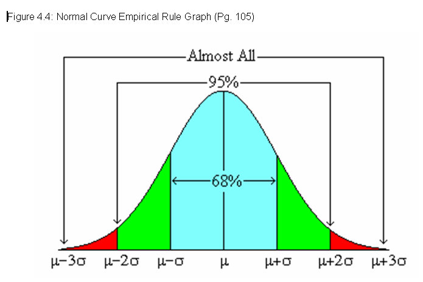

- Given \( X \sim N(\mu, \sigma^2) \), the empirical rule says:
- The probability that \( X \) is within **one** standard devation of the mean is 0.68:
- That is, \( P(\mu - \sigma < X < \mu + \sigma ) = 0.68 \).
- The probability that \( X \) is within **two** standard devations of the mean is 0.95.
- That is, \( P(\mu - 2\sigma < X < \mu + 2\sigma ) = 0.95 \).
- The probability that \( X \) is within **three** standard devations of the mean is 0.997.
- That is, \( P(\mu - 3\sigma < X < \mu + 3\sigma ) = 0.997 \).

### Your Turn

(1) Let \( X \sim N(100, 50^2) \). Find the following probabilities:

- \( P(X < 100) \)
- \( P(X < 150) \)
- \( P(100 < X < 150) \)
- \( P(X < 0) \)

(2) Suppose \( Z \sim N(0, 1) \). Find the following probabilities:

- \( P(Z < 0) \)
- \( P(Z < 1) \)
- \( P(0 < Z < 1) \)
- \( P(Z < -2) \)

### Standard Normal Distribution

- The **standard normal** distribution is a normal distribution with mean 0 and variance 1.
- We typically use \( Z \) to represent a standard normal distribution.
- It turns out that we can transform any \( X \sim N(\mu, \sigma) \) into \( Z \sim N(0,1) \) using a **z-score**:
- \[ z = \frac{x-\mu}{\sigma} \]
- Example(s) on board.